# Sampling Distributions

## Question 1 (4 points)

Let $X_i \sim N(20, 2)$ for $i = 1,2, \dots, 50$ and assume these are independent. What are the following?

- $\text{E}[20\bar{X} + 4]$
- $\text{SD}[30\bar{X} - 5]$

We have the following:

- $\text{E}[20\bar{X} + 4] = 404$
- $\text{SD}[30\bar{X} - 5] = \sqrt{900 \times \frac{4}{50}} = 30 \times \frac{2}{\sqrt{50}} \simeq 8.4853$

## Question 2A (9 points)

Let $X_i \sim N(10, 3)$ and $Y_i \sim N(20, 4)$ for $i = 1, 2, 3, \dots, 30$ and assume independence between all $X_i$ and $Y_i$. What is the sampling distribution of $\bar{X} + \bar{Y}$? Replace the $a$, $b$ and $c$ in the formula below with the correct values.

$$\bar{X} + \bar{Y} \sim N\left(30, \frac{5}{\sqrt{30}} \right)$$

Hint: Find the sampling distributions of $\bar{X}$ and $\bar{Y}$ first and then use the theorems regarding the expectation and variance of a linear combination of two independent random variables. Also, be sure to be careful when distinguishing between variance and standard deviation when applying these theorems.

We have that $\bar{X} \sim N\left(10, \frac{3}{\sqrt{30}} \right)$ and $\bar{Y} \sim N\left(20, \frac{4}{\sqrt{30}} \right)$.

We know that $\text{E}[X + Y] = \text{E}[X] + \text{E}[Y]$ so then $\text{E}[\bar{X} + \bar{Y}] = 10 + 20 = 30$. We know also know that for independent $X$ and $Y$ that $\text{Var}[X + Y] = \text{Var}[X] + \text{Var}[Y]$ so then $\text{Var}[\bar{X} + \bar{Y}] = \text{Var}[\bar{X}] + \text{Var}[\bar{Y}] = \frac{9}{30} + \frac{16}{30} = \frac{25}{30}$. This means that $\text{SD}[\bar{X} + \bar{Y}] = \sqrt{\text{Var}[\bar{X} + \bar{Y}]} = \frac{5}{\sqrt{30}}$. Thus,

$$\bar{X} + \bar{Y} \sim N\left(30, \frac{5}{\sqrt{30}} \right)$$

## Question 2B (5 points)

Complete the code block below to simulate draws from the sampling distribution of $\bar{X} + \bar{Y}$ from the previous question. Then compute the mean and standard deviation of the simulated draws and create a histogram of the draws.

```r
set.seed(100)

n_draws <- 100000 # Number of draws/simulations
n <- 30 # Sample size
xybars <- rep(0, n_draws) # Vector to stores draws for sum of sample means

mu_X <- 10
mu_Y <- 20
sigma_X <- 3
sigma_Y <- 4

for (i in 1:n_draws){
  x_sample <- rnorm(n, mu_X, sigma_X)
  y_sample <- rnorm(n, mu_Y, sigma_Y)

  xbar <- mean(x_sample)
  ybar <- mean(y_sample)
  xybars[i] <- xbar + ybar
}

mean(xybars)
```

```
[1] 29.99592
```

```r
sd(xybars)
```

```
[1] 0.9118258
```

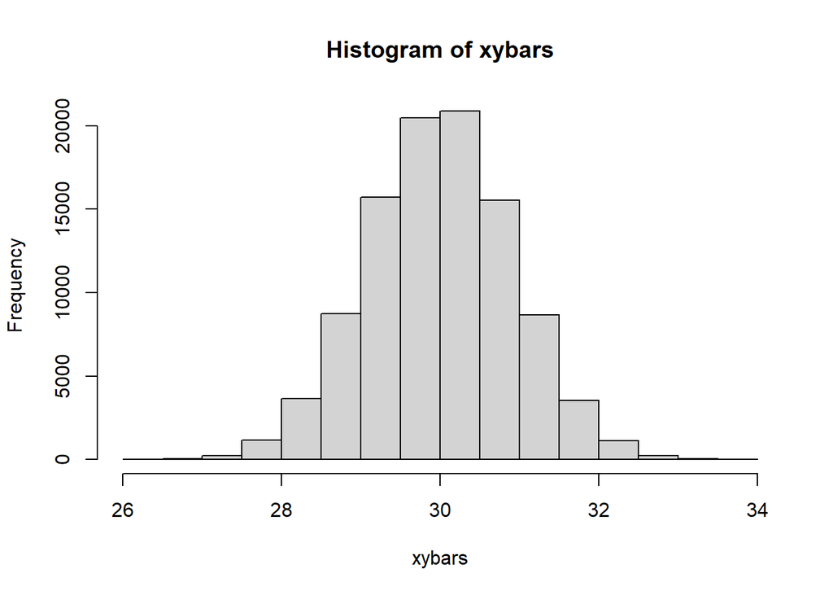

```r
hist(xybars)
```

## Question 3 (5 points)

Let $X_i \sim N(180, 10)$ for $i = 1, 2, 3, \dots, 64$. In the code block below, compute the following probabilities:

- $P(\bar{X} < 179)$
- $P(\bar{X} > 182)$
- $P(179 < \bar{X} < 182)$

```r
mu23 <- 180
sigma23 <- 10
n23 <- 64

# You could do it this way

pnorm(179, mu23, sigma23/sqrt(n23))
```

```
[1] 0.2118554
```

```r
1-pnorm(182, mu23, sigma23/sqrt(n23))
```

```
[1] 0.05479929
```

```r
pnorm(182, mu23, sigma23/sqrt(n23)) - pnorm(179, mu23, sigma23/sqrt(n23))
```

```
[1] 0.7333453
```

```r
# Or you could do it this way

pnorm((179-mu23)/(sigma23/sqrt(n23)))
```

```
[1] 0.2118554
```

```r
1-pnorm((182-mu23)/(sigma23/sqrt(n23)))
```

```
[1] 0.05479929
```

```r
pnorm((182-mu23)/(sigma23/sqrt(n23))) - pnorm((179-mu23)/(sigma23/sqrt(n23)))
```

```
[1] 0.7333453
```

## Question 4 (6 points)

Let $X_i \sim N(10, 2)$ for $i = 1,2,3,\dots, 50$. In the code block below, compute the following percentiles for $\bar{X}$:

- $85^{th}$ percentile
- $20^{th}$ percentile
- $1^{st}$ and $3^{rd}$ quartiles
- The median

```r
mu24 <- 10
sigma24 <- 2
n24 <- 50

# You could do it this way

qnorm(0.85, mu24, sigma24/sqrt(n24))
```

```
[1] 10.29315
```

```r
qnorm(0.2, mu24, sigma24/sqrt(n24))
```

```
[1] 9.761954
```

```r
qnorm(0.25, mu24, sigma24/sqrt(n24))
```

```
[1] 9.809225
```

```r
qnorm(0.75, mu24, sigma24/sqrt(n24))
```

```
[1] 10.19077
```

```r
qnorm(0.5, mu24, sigma24/sqrt(n24))
```

```
[1] 10
```

```r
# Or you could do it this way

qnorm(0.85)*sigma24/sqrt(n24) + mu24
```

```
[1] 10.29315
```

```r
qnorm(0.2)*sigma24/sqrt(n24) + mu24
```

```
[1] 9.761954
```

```r
qnorm(0.25)*sigma24/sqrt(n24) + mu24
```

```
[1] 9.809225
```

```r
qnorm(0.75)*sigma24/sqrt(n24) + mu24
```

```
[1] 10.19077
```

```r
qnorm(0.5)*sigma24/sqrt(n24) + mu24
```

```
[1] 10
```